# Deriving latent smoking variables using decision trees

Andrey Ziyatdinov

2017-03-23

# 1 About

Michael: Alternative modeling to that about SmokCigNow + Packs_Year

- Duration_Smoking + CigPerDaySmokAvg = Packs_Year
- CigPerDaySmokNow (cont.) = SmokCigNow (binary)

Idea: exploit all available variables to describe the smoking behavior:

- Use as many smoking variables as possible
- Train a machine learning model such as a decision tree
  - robust to missing data
  - produces latent grouping variables (6 boxes at the bottom of the next figure)
- Use output groups as a factor variable with many levels
  - Another random effect?
  - A fixed effect variables with many levels?
    - Use a method for many exposures that Jihye is currently developing
  - (todo) Use the standard measures (error in prediction, etc) to prove the proposed model is better than just linear regression with `SmokCigNow + Packs_Year`
- Do output groups have any sense for MDs? (Michael’s feedback is needed)

# 2 Data

```r
phen <- copdgene_phen(acs = "acs_global", progress = FALSE)
```

# 3 party: A Laboratory for Recursive Partytioning

ctree:

> an implementation of conditional inference trees which embed tree-structured regression models into a theory of conditional inference procedures.

> Unified tests for independence are constructed by means of the conditional distribution of linear statistics in the permutation test framework developed by Strasser and Weber (1999). The determination of the best binary split in one selected covariate and the handling of missing values is performed.

mob:

> implements an algorithm for recursive partitioning based on parametric models employing parameter instability tests for split selection.

```r
tree_control <- ctree_control(mincriterion = 0.99)
mob_control <- mob_control(alpha = 0.01)
mob_control2 <- mob_control(alpha = 0.1, bonferroni = TRUE, minsplit = 40)
```

## 3.1 Only smoking predictors

Remember also that the phenotype “FEV1pp” used to train the model has been adjusted for gender/age group/height/enth.

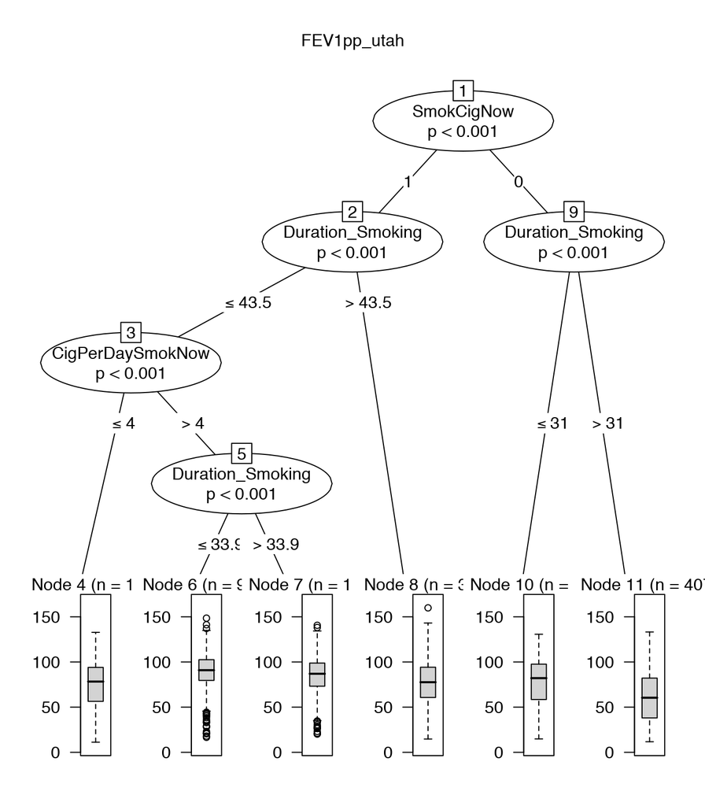

## 3.2 Smoking and other predictors

The next model used three more (non-smoking) variables: “Age_Enroll”, “gender”, “Height_CM”.

As a result, a good additional predictor is whether a subject is > 56 yrs under certain conditions.

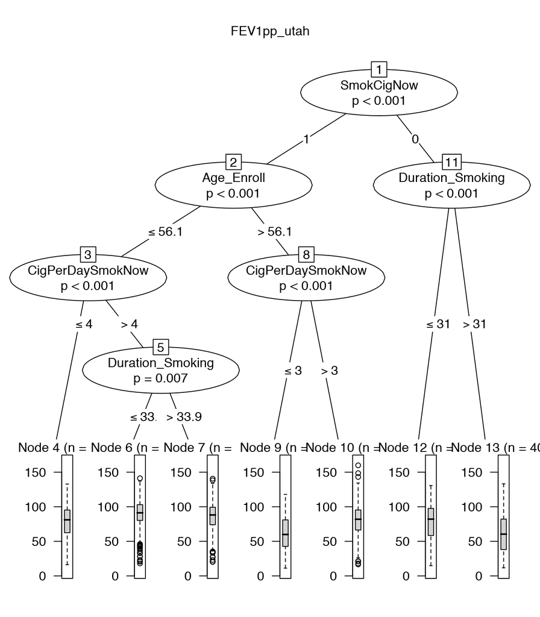

## 3.3 Predictors and smoking partitioning variables

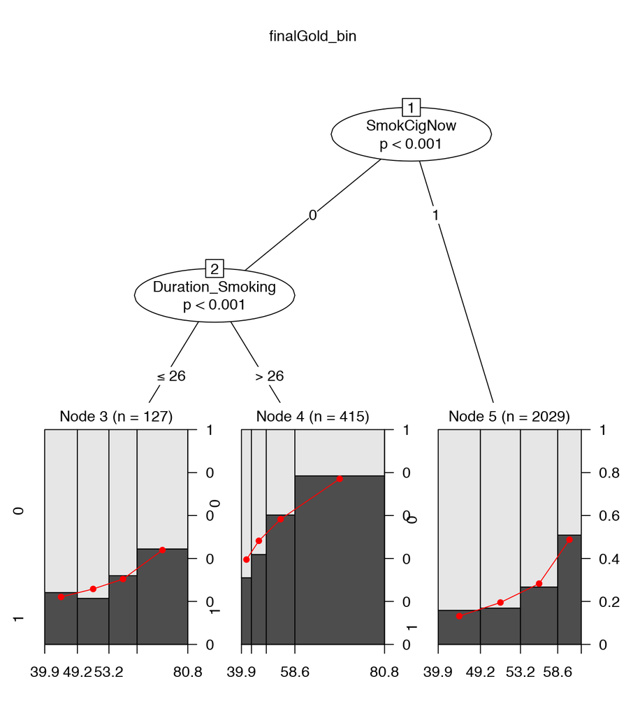

### 3.3.1 Discussion

Problem 1: missing values

Problem 2: inconsistency among variables